# Final Project for ML

lovenumbers123

March 17, 2017

## 1. Synopsis

Using devices such as Jawbone Up, Nike FuelBand or Fitbit, it is now possible to collect a large amount of data about personal activity relatively inexpensively. These type of devices are part of the quantified self movement. One thing that people regularly do is quantify how uch of a particular activity they do, but they rarely quantify how well they do it. In this project, the goal will be gto use data from accelerometers on the belt, forearm, arm and dumbell of six participants. They were asked to erpform barbell lifes correctly and incorrectly in five different ways.

The training data for this project are available here: https://d396qusza40orc.cloudfront.net/predmachlearn/pml-training.csv The test data are available here: https://d396qusza40orc.cloudfront.net/predmachlearn/pml-testing.csv

## 2. Data Processing

### Loading libraries, data and cleansing data

```r
library(caret)
library(rpart)
library (rattle)
```

```r
library(ggplot2)
library(dplyr)
library(randomForest)
trf <- "https://d396qusza40orc.cloudfront.net/predmachlearn/pml-training.csv"
tf <- "https://d396qusza40orc.cloudfront.net/predmachlearn/pml-testing.csv"
trd <- read.csv(url(trf), na.strings=c("NA","#DIV/0!",""))
td <- read.csv(url(tf), na.strings=c("NA","#DIV/0!",""))
```

#### Review data

```r
str(trd)
```

```
## 'data.frame':    19622 obs. of  160 variables:
##  $ X                       : int  1 2 3 4 5 6 7 8 9 10 ...
##  $ user_name               : Factor w/ 6 levels "adelmo","carlitos",..: 2 2 2 2 2 2 2 2 2 2 ...
##  $ raw_timestamp_part_1    : int  1323084231 1323084231 1323084231 1323084232 1323084232 1323084232 1323084232 1323084232 1323084232 1323084232 ...
##  $ raw_timestamp_part_2    : int  788290 808298 820366 120339 196328 304277 368296 440390 484323 484434 ...
##  $ cvtd_timestamp          : Factor w/ 20 levels "02/12/2011 13:32",..: 9 9 9 9 9 9 9 9 9 9 ...
##  $ new_window              : Factor w/ 2 levels "no","yes": 1 1 1 1 1 1 1 1 1 1 ...
##  $ num_window              : int  11 11 11 12 12 12 12 12 12 12 ...
##  $ roll_belt               : num  1.41 1.41 1.42 1.48 1.48 1.45 1.42 1.42 1.43 1.45 ...
##  $ pitch_belt              : num  8.07 8.07 8.07 8.05 8.07 8.06 8.09 8.13 8.16 8.17 ...
##  $ yaw_belt                : num  -94.4 -94.4 -94.4 -94.4 -94.4 -94.4 -94.4 -94.4 -94.4 -94.4 ...
##  $ total_accel_belt        : int  3 3 3 3 3 3 3 3 3 3 ...
##  $ kurtosis_roll_belt      : num  NA NA NA NA NA NA NA NA NA NA ...
##  $ kurtosis_picth_belt     : num  NA NA NA NA NA NA NA NA NA NA ...
##  $ kurtosis_yaw_belt       : logi  NA NA NA NA NA NA ...
```

[output cut: 86 more lines]

#### Remove NA’s, near zero variances and other data not pertinent to assignment

```r
rna <- sapply(trd, function(x) mean(is.na(x))) > 0.95
trd <- trd[, rna==F]
td <- td[, rna==F]

rnzv <- nearZeroVar(trd)
trd <- trd[, -rnzv]
td <- td[, -rnzv]

trd <- trd[, -c(1:6)]
td <- td[, -c(1:6)]
dim(trd)
```

```
## [1] 19622    53
```

```r
set.seed(711)
trsp <- createDataPartition(trd$classe, p=0.6, list=FALSE)
trs <- trd[trsp, ]
ts <- trd[-trsp, ]
dim(trs); dim(ts)
```

```
## [1] 11776    53
```

```
## [1] 7846   53
```

## 3. Modeling

#### Classification Tree

```r
kfc <- trainControl(method = "cv", number = 5)
fitkfc <- train(classe ~., data = trs, method = "rpart", trControl = kfc)
pdt <- rpart(classe ~., data=trs, method="class")
print (fitkfc, digits = 5)
```

```
## CART
##
## 11776 samples
##    52 predictor
##     5 classes: 'A', 'B', 'C', 'D', 'E'
##
## No pre-processing
## Resampling: Cross-Validated (5 fold)
## Summary of sample sizes: 9421, 9421, 9420, 9420, 9422
## Resampling results across tuning parameters:
##
##   cp        Accuracy  Kappa
##   0.040342  0.50696   0.362694
##   0.059287  0.41388   0.205617
##   0.112364  0.33101   0.071098
##
## Accuracy was used to select the optimal model using  the largest value.
## The final value used for the model was cp = 0.040342.
```

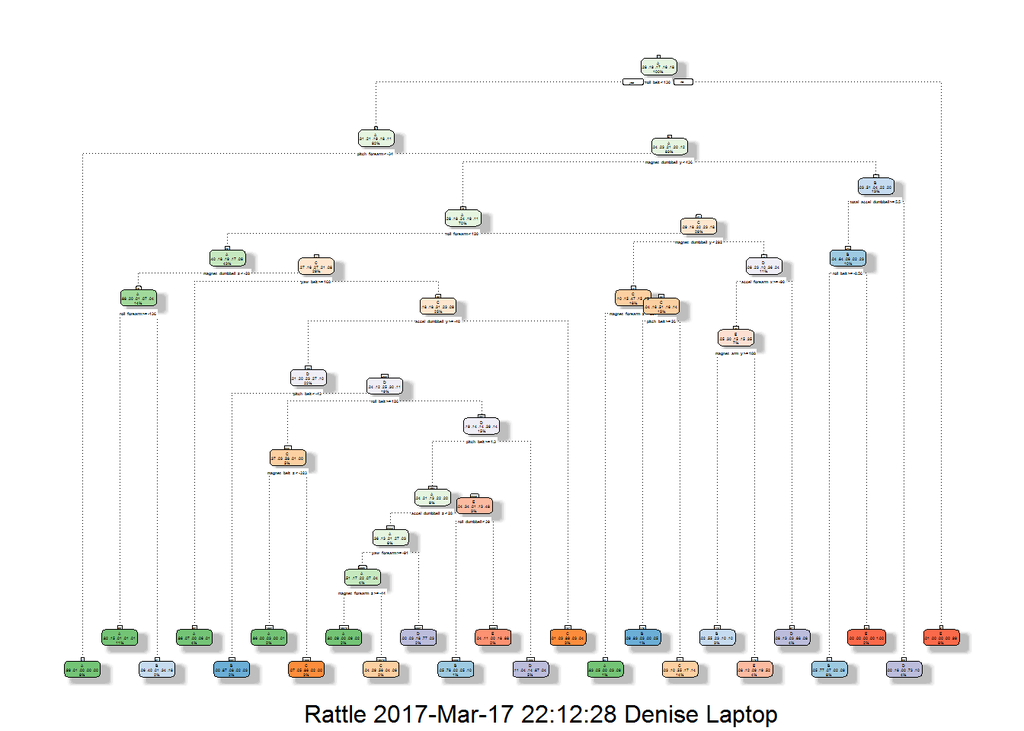

```r
fancyRpartPlot(pdt)
```

```r
prp <- predict(fitkfc, trs)
crp <- confusionMatrix(trs$classe, prp)
(arp <- crp$overall[1])
```

```
##  Accuracy
## 0.4920177
```

#### Random Forest

```r
fitrf <- train(classe ~., data = trs, method = "rf", trControl = kfc)
print (fitrf, digits = 5)
```

```
## Random Forest
##
## 11776 samples
##    52 predictor
##     5 classes: 'A', 'B', 'C', 'D', 'E'
##
## No pre-processing
## Resampling: Cross-Validated (5 fold)
## Summary of sample sizes: 9422, 9420, 9420, 9421, 9421
## Resampling results across tuning parameters:
##
##   mtry  Accuracy  Kappa
##    2    0.98794   0.98474
##   27    0.98879   0.98582
##   52    0.98344   0.97905
##
## Accuracy was used to select the optimal model using  the largest value.
## The final value used for the model was mtry = 27.
```

```r
prf <- predict(fitrf, trs)
(crf <- confusionMatrix(trs$classe, prf))
```

```
## Confusion Matrix and Statistics
##
##           Reference
## Prediction    A    B    C    D    E
##          A 3348    0    0    0    0
##          B    0 2279    0    0    0
##          C    0    0 2054    0    0
##          D    0    0    0 1930    0
##          E    0    0    0    0 2165
##
## Overall Statistics
##
##                Accuracy : 1
##                  95% CI : (0.9997, 1)
##     No Information Rate : 0.2843
##     P-Value [Acc > NIR] : < 2.2e-16
##
##                   Kappa : 1
##  Mcnemar's Test P-Value : NA
##
## Statistics by Class:
##
##                      Class: A Class: B Class: C Class: D Class: E
## Sensitivity            1.0000   1.0000   1.0000   1.0000   1.0000
## Specificity            1.0000   1.0000   1.0000   1.0000   1.0000
## Pos Pred Value         1.0000   1.0000   1.0000   1.0000   1.0000
## Neg Pred Value         1.0000   1.0000   1.0000   1.0000   1.0000
## Prevalence             0.2843   0.1935   0.1744   0.1639   0.1838
## Detection Rate         0.2843   0.1935   0.1744   0.1639   0.1838
## Detection Prevalence   0.2843   0.1935   0.1744   0.1639   0.1838
## Balanced Accuracy      1.0000   1.0000   1.0000   1.0000   1.0000
```

```r
(arf <- crf$overall[1])
```

```
## Accuracy
##        1
```

#### Predict Test Set

```r
(predict(fitrf, td))
```

```
##  [1] B A B A A E D B A A B C B A E E A B B B
## Levels: A B C D E
```

## 4. Conclusion

The random forest method is more accurate than the classification tree. The accuracy rate rounds to 100%; whereas the classification tree is only 49%. The random forest method takes a long time to process. So, if there is a time constraint, additional methods should be researched to determine if there is a speedier method.